# Ggplot2 tutorial R buddy

Hannah

2022-11-23

This is a beginner tutorial that introduces you to

- scatter plots
- adding trend lines
- adding labels
- changing colours
- plotting summary stats (mean, error bars)
- combining plots

You can use the data introduced below or your own data. If you use your own data, you will have to adapt the code to your data.

```r
remotes::install_github("romunov/AED")

library(ggplot2)
library(remotes)
library(AED)
library(cowplot)
```

```r
citation("ggplot2")
```

```
##
##
##   H. Wickham. ggplot2: Elegant Graphics for Data Analysis.
##   Springer-Verlag New York, 2016.
##
## A BibTeX entry for LaTeX users is
##
##   @Book{,
##     author = {Hadley Wickham},
##     title = {ggplot2: Elegant Graphics for Data Analysis},
##     publisher = {Springer-Verlag New York},
##     year = {2016},
##     isbn = {978-3-319-24277-4},
##     url = {https://ggplot2.tidyverse.org},
##   }
```

### About the data set

“RIKZ” is a data set of Alain Zuur, author of the book “Mixed effects models and extensions in ecology with R” (2009). It’s in the AED package, which you find on github. The data set is on macrofauna species richness (response variable) measured at 9 different beaches at different distances from the sampling station to the tidal level (NAP) and at different expositions. The main interest is whether NAP and exposition affect macrofauna species richness.

```r
# download data from the AED package

data("RIKZ")
head(RIKZ)
```

```
##   Sample Richness Exposure    NAP Beach
## 1      1       11       10  0.045     1
## 2      2       10       10 -1.036     1
## 3      3       13       10 -1.336     1
## 4      4       11       10  0.616     1
## 5      5       10       10 -0.684     1
## 6      6        8        8  1.190     2
```

### ggplot()

This function creates a basic plot background

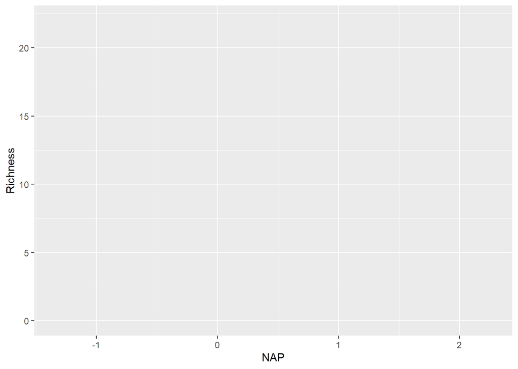

```r
ggplot(RIKZ, aes(x = NAP, y = Richness))
```

### Scatter plot

Add a geom object to the plot to visualize data. Check out the different themes which you can add with the cowplot package (https://cran.r-project.org/web/packages/cowplot/vignettes/introduction.html).

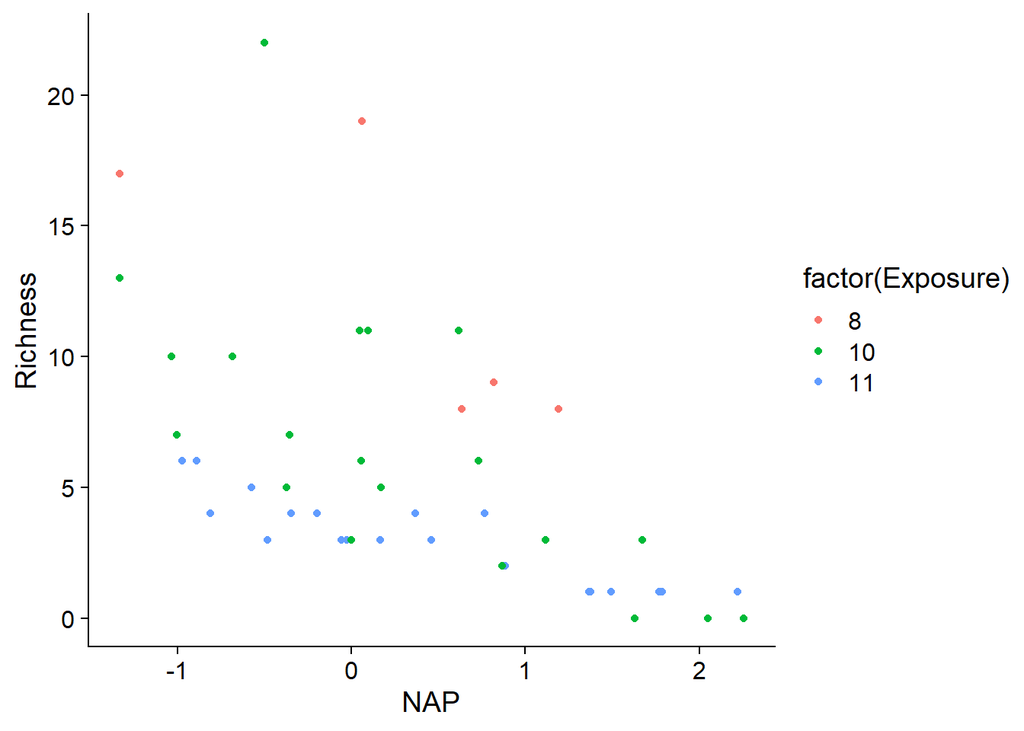

```r
ggplot(RIKZ, aes(x = NAP, y = Richness, colour = factor(Exposure))) +
  geom_point() +
  theme_cowplot()
```

### Trendlines

We can add a trendline to the scatterplot. The method “lm” fits a linear model. “rml” is part of the “MASS” package and more robust because outliers do not affect the fit as much as in “lm”. Do you see a difference between the two methods?

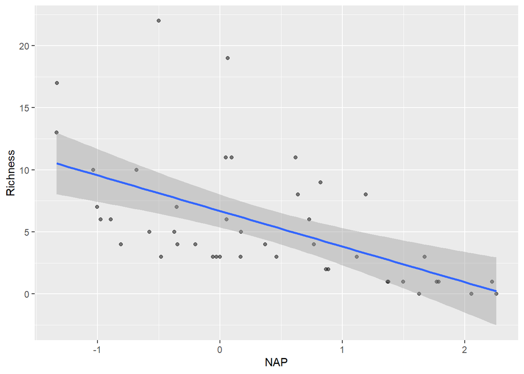

```r
ggplot(RIKZ, aes(x = NAP, y = Richness)) +
  geom_point(alpha=.5) +
  geom_smooth(method=lm)
```

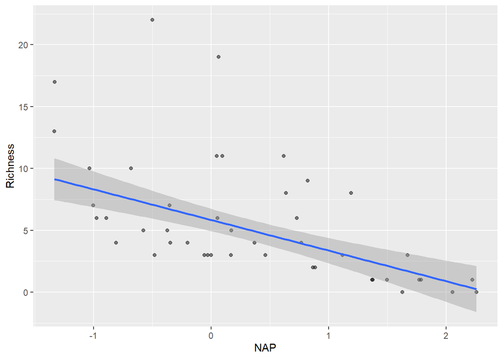

```r
library(MASS)

ggplot(RIKZ, aes(x = NAP, y = Richness)) +
  geom_point(alpha=.5) +
  geom_smooth(method=rlm)
```

Now lets see whether there are differences in the relationship between X and Y for the third variable. The next plot draws a trendline for the groups of this third variable separately.

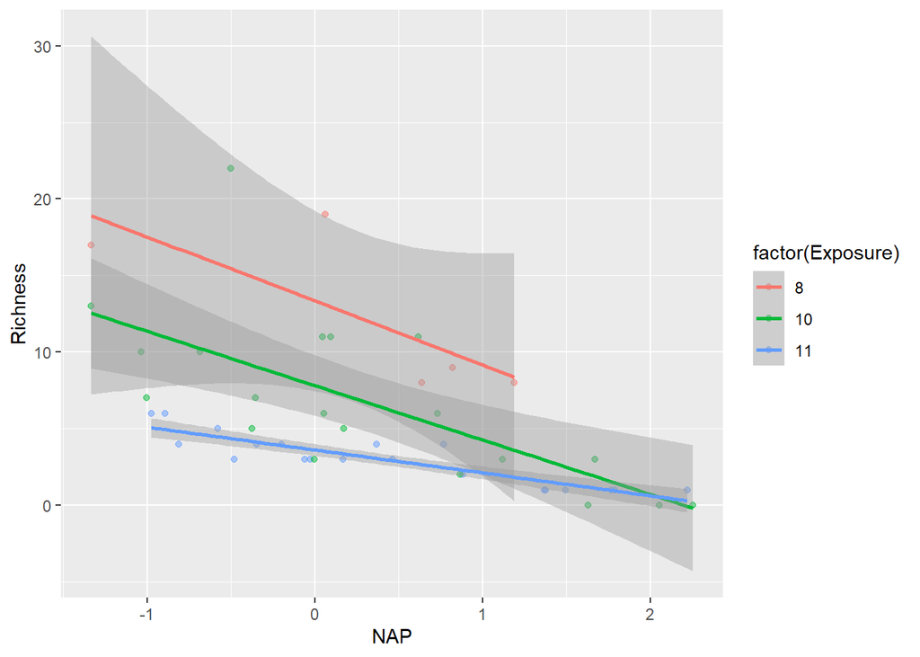

```r
ggplot(RIKZ, aes(x = NAP, y = Richness, colour = factor(Exposure))) +
  geom_point(alpha=.5) + # alpha sets the strength of the points
  geom_smooth(method=lm)
```

### Facets

We can also make separate plots for the different groups of the third variable with facet_wrap or facet_grid.

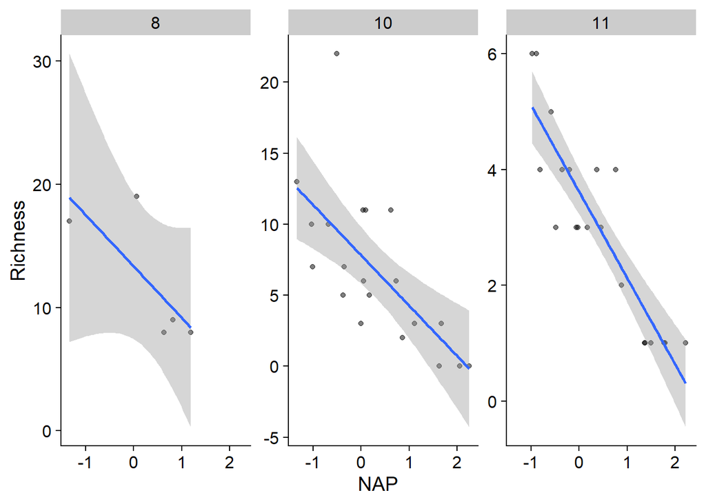

```r
ggplot(RIKZ, aes(x = NAP, y = Richness)) +
  geom_point(alpha=.5) +
  geom_smooth(method=lm) +
  facet_wrap(~Exposure,
             scales = "free_y") +
          # check out the different scale options "free_x", "free", "fixed"
  theme_cowplot()
```

### Labels

Now, add a title and a subtitle to the plot and change the axes labels. Note that there is a lot of redundancy and that in this case the labels are probably not necessary.

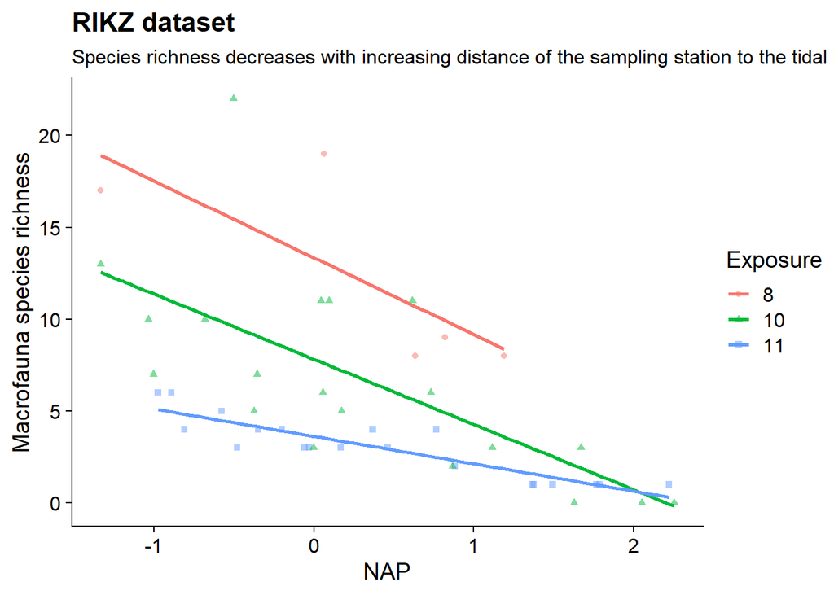

```r
ggplot(RIKZ, aes(x = NAP, y = Richness, shape = factor(Exposure), colour = factor(Exposure))) +
  geom_point(alpha=.5) +
  geom_smooth(se = FALSE, method=lm) +
  labs(title = "RIKZ dataset",
       subtitle = "Species richness decreases with increasing distance of the sampling station to the tidal level (NAP)",
       x = "NAP",
       y = "Macrofauna species richness",
       shape = "Exposure",
       colour = "Exposure") +
  theme_cowplot()
```